# Kolokwium 31.01.2023 - zadanie 2

Do zadań należy wykorzystać zbiór danych umieszczony w pliku `breast_cancer.txt`. Zawiera on 699 obserwacji 11 zmiennych opisujących różne parametry komórek nowotworu piersi. Pierwsza zmienna jest identyfikatorem pacjenta, kolejnych dziewięć jest typu numerycznego o wartościach całkowitych od 1 do 10. Zmienna `Class` określa, czy nowotwór został oceniony jako łagodny czy złośliwy. Opisy kolumny są następujące:

| L.p. | Nazwa | Opis |
| --- | --- | --- |
| [,1] | Id | Sample code number |
| [,2] | Cl.thickness | Clump Thickness |
| [,3] | Cell.size | Uniformity of Cell Size |
| [,4] | Cell.shape | Uniformity of Cell Shape |
| [,5] | Marg.adhesion | Marginal Adhesion |
| [,6] | Epith.c.size | Single Epithelial Cell Size |
| [,7] | Bare.nuclei | Bare Nuclei |
| [,8] | Bl.cromatin | Bland Chromatin |
| [,9] | Normal.nucleoli | Normal Nucleoli |
| [,10] | Mitoses | Mitoses |
| [,11] | Class | benign or malignant |

**1. (1 pkt.)** Wczytaj dane z pliku i upewnij się, że kolumny są odpowiedniego typu. Usuń rekordy zawierające brakujące obserwacje.

**3. (1 pkt.)** Podziel zbiór danych na próbę uczącą i testową w stosunku 1:1. Na próbie uczącej wytrenuj regresję logistyczną, a następnie dla próby testowej wyznacz prawdopodobieństwa tego, że nowotwór jest złośliwy.

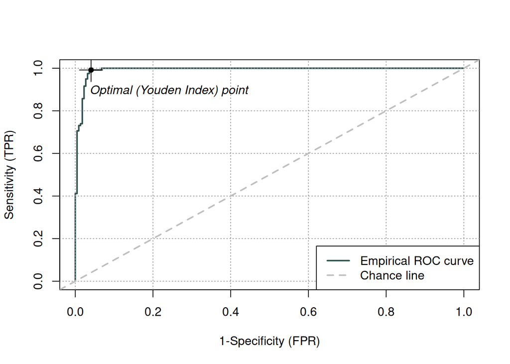

**5. (1 pkt.)** Wykorzystaj znaleziony próg do zamiany prawdopodobieństw na klasy, a następnie wykonaj i wyświetl macierz pomyłek oraz dokładność klasyfikatora.

```
## Confusion Matrix and Statistics
##
##            Reference
## Prediction  benign malignant
##   benign       213         2
##   malignant      9       117
##
##                Accuracy : 0.9677
##                  95% CI : (0.943, 0.9838)
##     No Information Rate : 0.651
##     P-Value [Acc > NIR] : < 2e-16
##
##                   Kappa : 0.93
##
##  Mcnemar's Test P-Value : 0.07044
##
##             Sensitivity : 0.9832
##             Specificity : 0.9595
##          Pos Pred Value : 0.9286
##          Neg Pred Value : 0.9907
##              Prevalence : 0.3490
##          Detection Rate : 0.3431
##    Detection Prevalence : 0.3695
##       Balanced Accuracy : 0.9713
##
##        'Positive' Class : malignant
##
```

**6. (1 pkt.)** Dla pełnych danych przeprowadź 10-krotną walidację krzyżową z trzema powtórzeniami. Testy przeprowadź dla trzech metod: drzew losowych, LDA i QDA. Wyświetl dokładność każdej z metod.

```
## CART
##
## 683 samples
##   4 predictor
##   2 classes: 'benign', 'malignant'
##
## No pre-processing
## Resampling: Cross-Validated (10 fold, repeated 3 times)
## Summary of sample sizes: 614, 615, 615, 615, 615, 614, ...
## Resampling results across tuning parameters:
##
##   cp          Accuracy   Kappa
##   0.04393305  0.9160906  0.8192070
##   0.05020921  0.9067760  0.7995422
##   0.74895397  0.7681429  0.3837156
##
## Accuracy was used to select the optimal model using the largest value.
## The final value used for the model was cp = 0.04393305.
```

```
## Linear Discriminant Analysis
##
## 683 samples
##   4 predictor
##   2 classes: 'benign', 'malignant'
##
## No pre-processing
## Resampling: Cross-Validated (10 fold, repeated 3 times)
## Summary of sample sizes: 615, 615, 614, 615, 614, 615, ...
## Resampling results:
##
##   Accuracy   Kappa
##   0.9575226  0.9052259
```

```
## Quadratic Discriminant Analysis
##
## 683 samples
##   4 predictor
##   2 classes: 'benign', 'malignant'
##
## No pre-processing
## Resampling: Cross-Validated (10 fold, repeated 3 times)
## Summary of sample sizes: 615, 615, 614, 615, 615, 615, ...
## Resampling results:
##
##   Accuracy   Kappa
##   0.9609893  0.9156882
```